# 07_classification2_py slides

## DSCI 100 - Introduction to Data Science

### Lecture 7 - Classification II: Evaluating & Tuning

[figure not shown]

## Housekeeping

- Midterm on Thursday at 12:30
- Covers weeks 1-6
  - Introduction to Python and Pandas ([Ch 1 in textbook](https://python.datasciencebook.ca/intro.html))
  - Reading Data ([Ch 2](https://python.datasciencebook.ca/reading.html))
  - Wrangling Data ([Ch 3](https://python.datasciencebook.ca/wrangling.html))
  - Visualizing Data ([Ch 4](https://python.datasciencebook.ca/viz.html))
  - Version Control ([Ch 12](https://python.datasciencebook.ca/version-control.html))
  - Classification I: training & predicting ([Ch 5](https://python.datasciencebook.ca/classification1.html))
- quiz is 70 minutes
  - Multiple choice
  - Short answer
  - Fill in the blank coding questions
- on Canvas with lockdown browser
  - use Chrome or Firefox. Disable browser extensions
  - You will be able to access the [Reference sheet for Python](https://ubc-dsci.github.io/dsci-100-student/REFERENCE_PYTHON.html)
  - Please bring a calculator

## Today: unanswered questions from last week

1. Is our model any good? How do we **evaluate** it?
2. How do we choose `k` in K-nearest neighbours classification?

## How to measure classifier performance?

### Accuracy

$$Accuracy = \dfrac{\#\; correct\; predictions}{\#\; total\; predictions}$$

### Confusion matrix

Here is an example of confusion matrix with cancer diagnosis data we've seen before.

|  | Truly Malignant | Truly Benign |
| --- | --- | --- |
| **Predicted Malignant** | 1 | 4 |
| **Predicted Benign** | 3 | 57 |

Typically we consider one of the class labels as "positive" - in this case the "Malignant" status is more interesting to researchers, hence we consider that label as "positive".

Relabeling the above confusion matrix:

|  | Truly Positive | Truly Negative |
| --- | --- | --- |
| **Predicted Positive** | 1 | 4 |
| **Predicted Negative** | 3 | 57 |

Note that:

- Top left cell = # correct positive predictions.
- Top *row* = # total positive predictions.
- Left *column* = # truly positive observations.

### Precision and Recall

$$ {Precision} = \dfrac{{\#\; correct\; positive\; predictions}}{{\#\; total\; positive\; predictions}} \quad\quad\quad \quad {Recall} = \dfrac{{\#\; correct\; positive\; predictions}}{{\#\; total\; truly\; positive\; observations}} $$

In the above confusion matrix, precision = 1/(1+4) and recall = 1/(1+3).

### How good is good and which metric's more important?

...is application context dependent. Use your judgement.

For example:

- a 99% accuracy on cancer prediction may not be very useful. Why?
- If we need patients with truly malignant cancer to be diagnosed correctly, what metric should we prioritize?
- What if a classifier never guess positive except for the very few observations it is super confident in? What metric is affected?

## Adding evaluation to the pipeline for building a classifier

To add evaluation into our classification pipeline, we:

1. Split our data into two subsets: *training data* and *testing data*.
2. Build the model & choose K using training data only (sometimes called tuning)
3. Compute performance metrics (accuracy, precision, recall, etc.) by predicting labels on testing data only

We'll now talk about each step individually.

[figure not shown]

## Tuning and evaluating the Model

[figure not shown]

**Golden Rule of Machine Learning / Statistics:** *Don't use your testing data to train your model!*

## Why?

Showing your classifier the labels of evaluation data is like cheating on a test; it'll look more accurate than it really is

- "training your model" includes choosing K, choosing predictors, choosing the model, scaling/centering variables, etc!

[figure not shown]

## Splitting Data

There are two important things to do when splitting data.

1. **Shuffling:** randomly reorder the data before splitting
2. **Stratification:** make sure the two split subsets of data have roughly equal proportions of the different labels

[figure not shown]

**Why?**

(`sklearn` thankfully automatically does both of these things)

## Choosing K (or, "tuning'' the model)

Want to choose K to maximize accuracy, but:

- we can't use test data to evaluate performance (cheating!)
- we can't use training data to evaluate performance (choosing K is part of training!)

**Solution:** Split the training data further into *training data* and *validation data sets*

2a. Choose some candidate values of K  
2b. Split the **training data** into two sets - one called the **training set**, another called the **validation set**  
2c. For each K, train the model using **training set only**  
2d. Evaluate accuracy (and/or other metrics of performance) for each using **validation set only**  
2e. Pick the K that maximizes validation accuracy

*But what if we get a bad training set? Just by chance?*

## Cross-Validation

We can get a better estimate of performance by splitting *multiple ways* and *averaging*

[figure not shown]

## Underfitting & Overfitting

**Overfitting:** when your model is too sensitive to your training data; noise can influence predictions!

**Underfitting:** when your model isn't sensitive enough to training data; useful information is ignored!

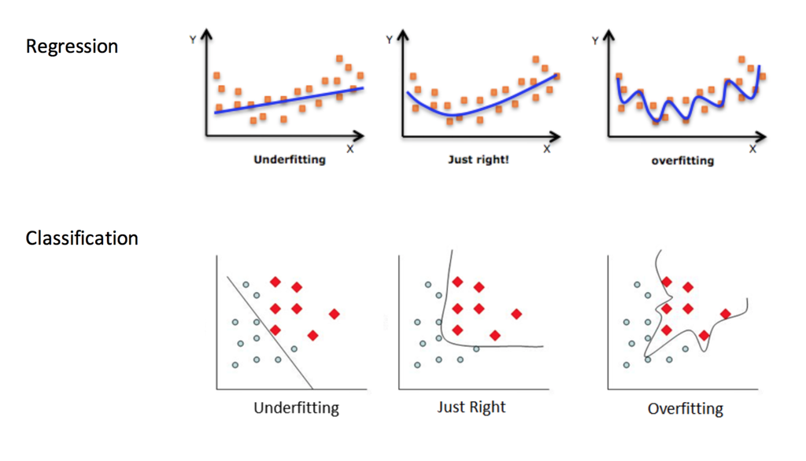

Source: http://kerckhoffs.schaathun.net/FPIA/Slides/09OF.pdf

## Underfitting & Overfitting

**Which of these are under-, over-, and good fits?**

[figure not shown]

## Underfitting & Overfitting

For KNN: small K overfits, large K underfits, both cause lower accuracy

[figure not shown]

## The Big Picture

[figure not shown]

## Worksheet Time! Go for it!

1. Go to your **project groups**
2. You can work on the worksheet or discuss your group project proposal if needed